# Chapter 6 - Clustering

### * Hierarchical Clustering

## Clustering - $k$-Means Clustering

The idea behind $k$-means clustering is that a good clustering is one for which the *within-cluster variation* is as small as possible. We want to minimise
$$\min_{C_1,\dots,C_K} \Big\{ \sum^K_{k=1}{\frac{1}{|C_k|}\sum_{i,i'\in C_k}\sum_{j=1}^p(x_{i,j} - x_{i'j})^2}\Big\},$$
where $C_k$ denotes the number of observations in the $k$-th cluster.

### $k$-Means Clustering Algorithm:

- Randomly assign a number, from 1 to k, to each of the observations. These serve as initial cluster assignments for the observations.
- Iterate until the cluster assignments stop changing:
  - For each of the $k$ clusters, compute the cluster **centroid**. The $k$th cluster centroid is the vector of the $p$ feature means for the observations in the $k$th cluster.
  - Assign each observation to the cluster whose centroid is closest (where closest is defined using Euclidean distance).

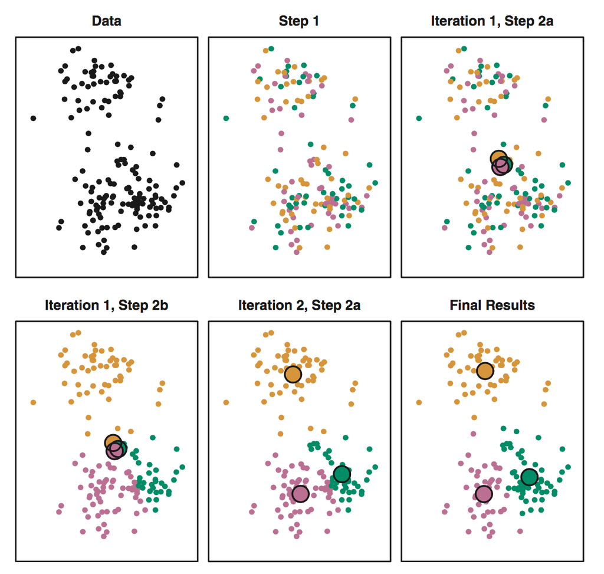

The function `kmeans()` performs $k$-means clustering in R. We begin with a simple simulated example in which there truly are two clusters in the data: the first 25 observations have a mean shift relative to the next 25 observations.

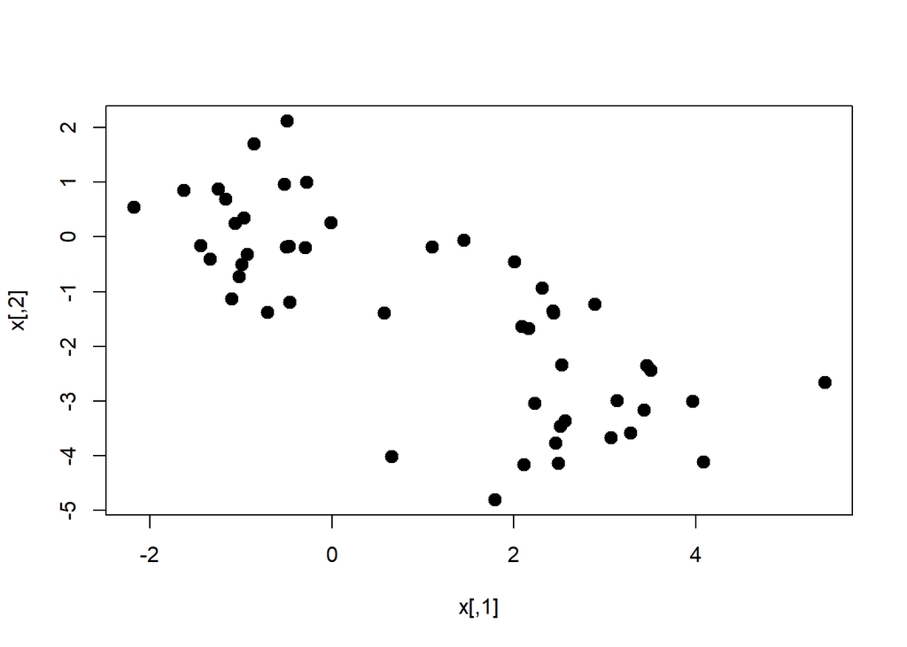

```r
# Generate an example dataset:
set.seed(1234)
# Generate a 50-by-2 Matrix, filled by std. normal dist.
x = matrix(data = rnorm(n = 100), ncol = 2)

# for the first 25 obs, x1(x axis) + 3
# for the first 25 obs, x2(y axis) - 3
x[1:25,1] = x[1:25,1] + 3
x[1:25,2] = x[1:25,2] - 3
plot(x, pch = 20, cex = 2)
```

We strongly recommend always running $k$-means clustering with a large value of nstart, such as 20 or 50, since otherwise an undesirable local optimum may be obtained.

```r
km_cluster = kmeans(x = x, centers = 2, nstart = 50)
```

The $k$-means clustering perfectly separated the observations into two clusters even though we did not supply any group information to kmeans(). We can plot the data, with each observation colored according to its cluster assignment.

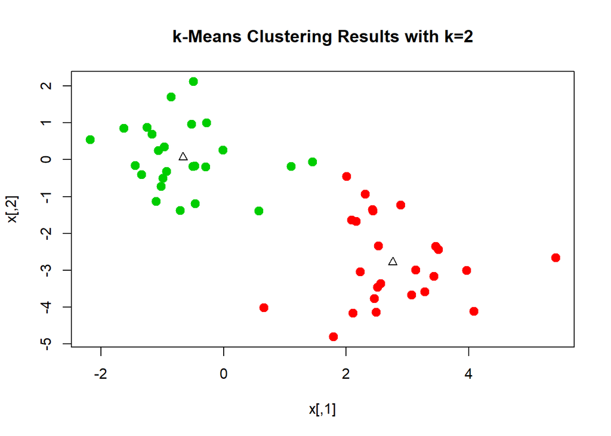

```r
plot(x, col = (km_cluster$cluster + 1),
    main = "k-Means Clustering Results with k=2",
    pch = 20,
    cex = 2)
points(km_cluster$centers, pch = 2)
```

for real data, in general we do not know the true number of clusters. We could instead performed $k$-means clustering on this example with $k$ = 4

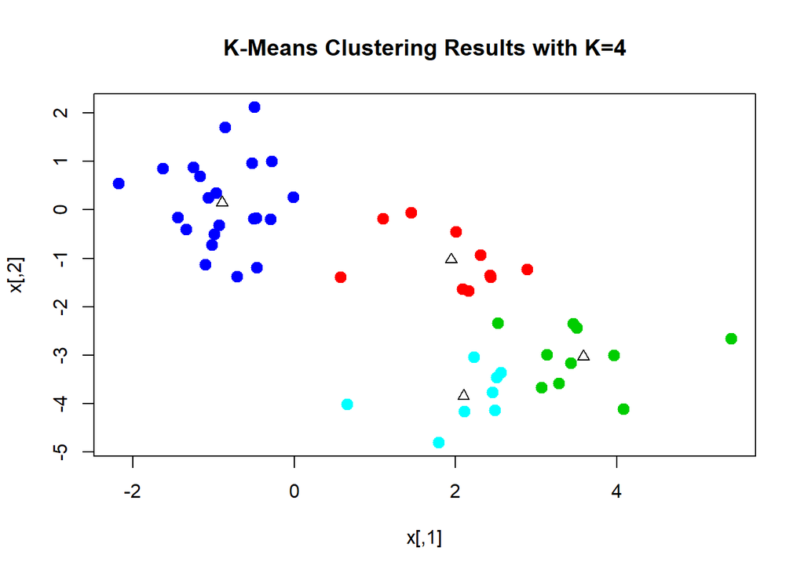

```r
km_cluster = kmeans(x = x, centers = 4, nstart = 50)
plot(x, col = (km_cluster$cluster + 1),
    main = "K-Means Clustering Results with K=4",
    pch = 20,
    cex = 2)
points(km_cluster$centers, pch = 2)
```

## Hierarchical Clustering

One potential disadvantage of **$k$-means clustering** is that it requires us to pre-specify the number of clusters $k$. **Hierarchical clustering** is an alternative approach which does not require that we commit to a particular choice of $k$.

### Hierarchical Clustering Algorithm:

- Begin with $n$ observations and a measure (such as Euclidean distance) of all the $\binom{2}{n} = n(n -1)/2$ pairwise dissimilarities. Treat each observation as its own cluster.
- For $i = n, n-1, \dots, 2:$
  - Examine all pairwise inter-cluster dissimilarities among the i clusters and identify the pair of clusters that are least dissimilar (that is, most similar). Fuse these two clusters. The dissimilarity between these two clusters indicates the height in the dendrogram at which the fusion should be placed.
  - Compute the new pairwise inter-cluster dissimilarities among the $i - 1$ remaining clusters.

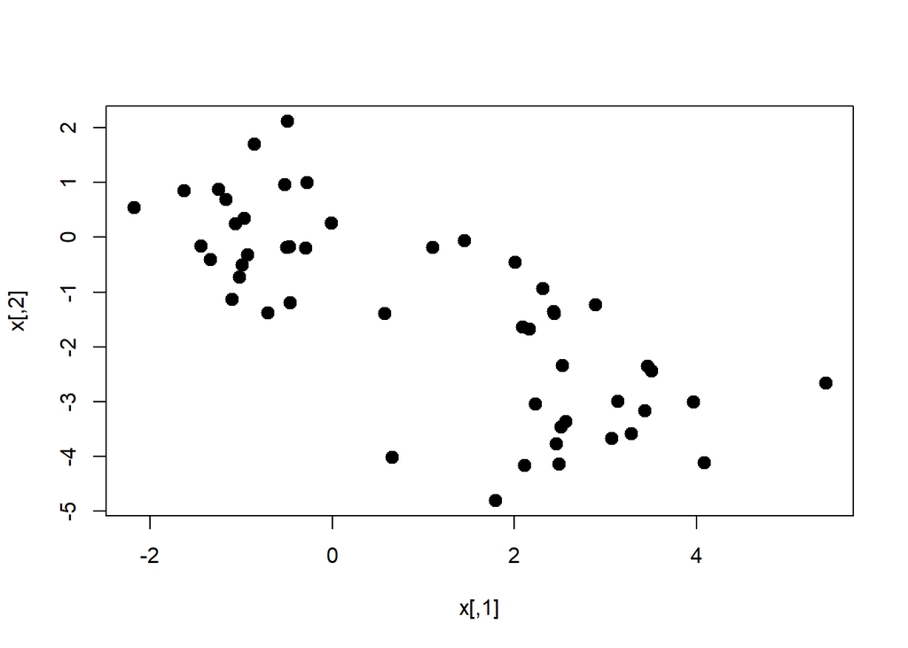

```r
# Generate an example dataset:
set.seed(1234)
# Generate a 50-by-2 Matrix, filled by std. normal dist.
x = matrix(data = rnorm(n = 100), ncol = 2)

# for the first 25 obs, x1(x axis) + 3
# for the first 25 obs, x2(y axis) - 3
x[1:25,1] = x[1:25,1] + 3
x[1:25,2] = x[1:25,2] - 3
plot(x, pch = 20, cex = 2)
```

The `hclust()` function implements hierarchical clustering in R. In the following example, we use the data from the last part to plot the hierarchical clustering dendrogram using complete, single, and average linkage clustering, with Euclidean distance as the dissimilarity measure. We begin by clustering observations using complete linkage. The `dist()` function is used to compute the inter-observation Euclidean distance matrix.

The dist() function is used to compute the pairwise inter-observation Euclidean/maximum/manhattan… distance matrix.

```r
d_euc = dist(x, method = "euclidean")
```

The hclust() function implements hierarchical clustering in R. In the following example we use the data from the last part to plot the hierarchical clustering dendrogram using complete, single, and average linkage clustering, with Euclidean distance as the dissimilarity measure.

```r
hc_complete = hclust(d = d_euc, method = "complete")
hc_average = hclust(d = d_euc, method = "average")
hc_single = hclust(d = d_euc, method = "single")
```

We can now plot the dendrograms obtained using the usual `plot()` function. The numbers at the bottom of the plot identify each observation.

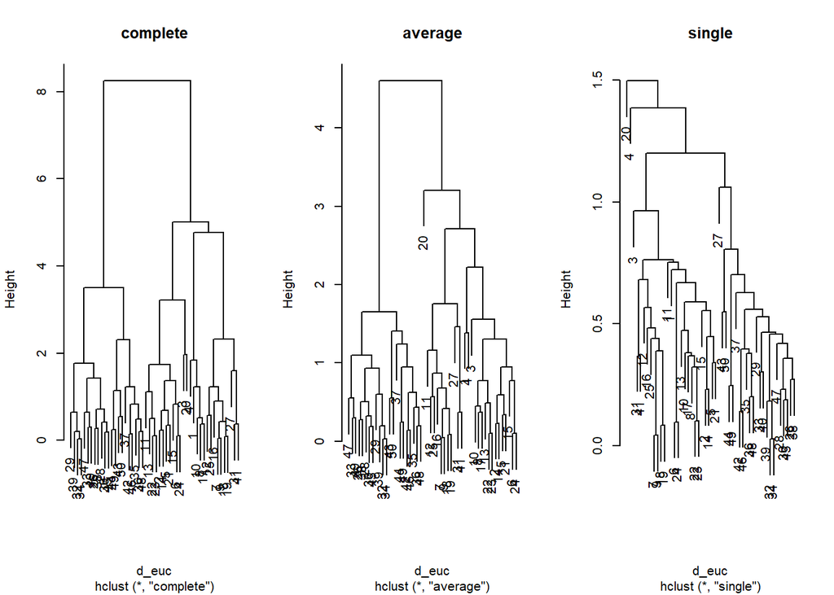

```r
par(mfrow = c(1, 3))
plot(hc_complete, main = "complete")
plot(hc_average, main = "average")
plot(hc_single, main = "single")
```

To determine the cluster labels for each observation associated with a given cut of the dendrogram, we can use the `cutree()` function.

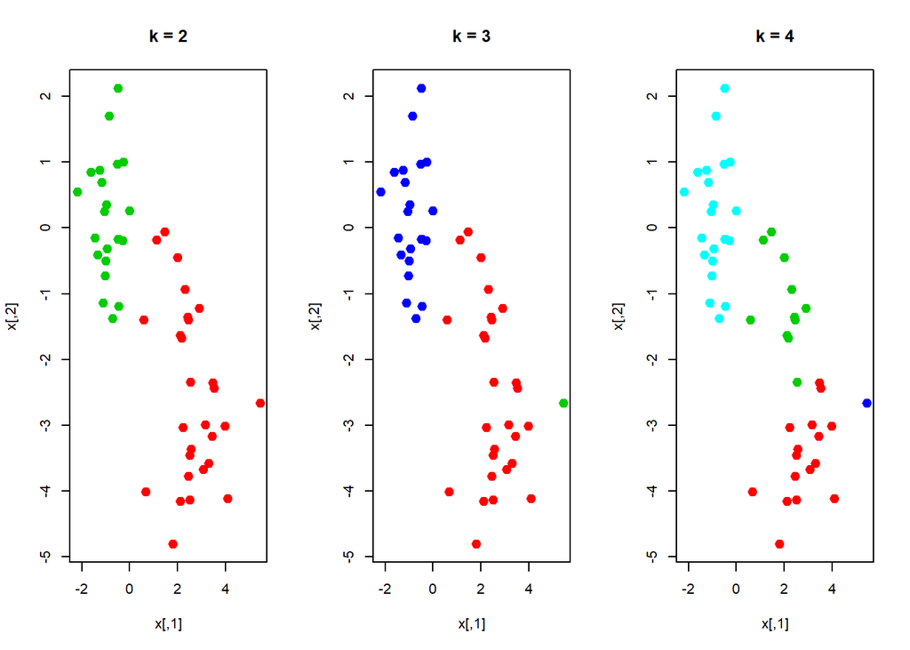

```
##  [1] 1 1 1 1 1 1 1 1 1 1 1 1 1 1 1 1 1 1 1 1 1 1 1 1 1 2 1 2 2 2 1 2 2 2 2
## [36] 2 2 2 2 2 1 2 2 2 2 2 2 2 2 2
##  [1] 1 1 1 1 1 1 1 1 1 1 1 1 1 1 1 1 1 1 1 2 1 1 1 1 1 3 1 3 3 3 1 3 3 3 3
## [36] 3 3 3 3 3 1 3 3 3 3 3 3 3 3 3
##  [1] 1 1 1 1 1 1 2 1 2 1 2 2 1 1 1 2 1 2 2 3 1 1 1 1 2 4 2 4 4 4 2 4 4 4 4
## [36] 4 4 4 4 4 2 4 4 4 4 4 4 4 4 4
```

```r
par(mfrow = c(1, 3))
cutree(tree = hc_average, k = 2)
plot(x, col = cutree(hc_average, k = 2) + 1, pch = 20, cex = 2, main = "k = 2")

cutree(tree = hc_average, k = 3)
plot(x, col = cutree(hc_average, k = 3) + 1, pch = 20, cex = 2,  main = "k = 3")

cutree(tree = hc_average, k = 4)
plot(x, col = cutree(hc_average, k = 4) + 1, pch = 20, cex = 2,  main = "k = 4")
```

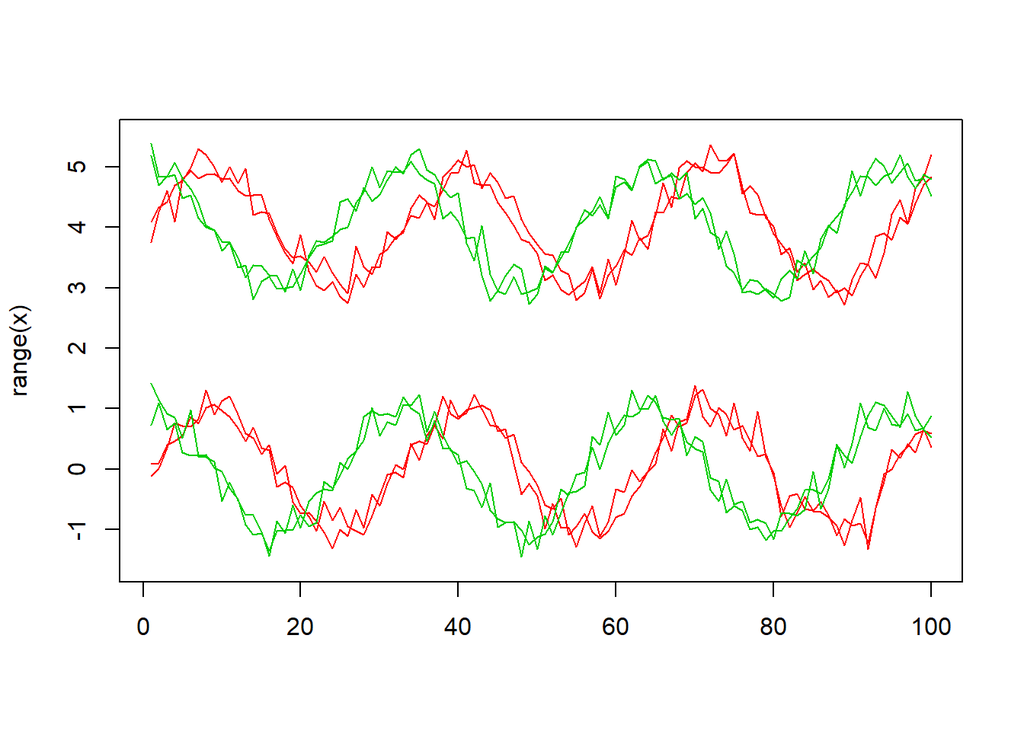

```r
# Generate a sample dataset:
# 50 obs. are "curves", first 25 obs are sin, last 25 are cos
# 1, 3, 5, ..., 49 are around 4; 2, 4, .. 50 are around 0
set.seed(1234)
x0 = seq(0, 2*pi, length.out = 100)
x = matrix(0, nrow = 50, ncol = 100)
for(i in 1:50){
    if(i <=25){
        # %%: remainder after the exact division
        x[i,] = sin(x0*pi) + (i%%2)*4 + rnorm(100, sd = 0.2)
    }else{
        x[i,] = cos(x0*pi) + (i%%2)*4 + rnorm(100, sd = 0.2)
    }
}

# plot() the data
plot(x = c(1, 100), y = range(x), type = "n", xlab = "")
lines(x[1,], col = 2)
lines(x[2,], col = 2)
lines(x[3,], col = 2)
lines(x[4,], col = 2)
lines(x[26,], col = 3)
lines(x[27,], col = 3)
lines(x[28,], col = 3)
lines(x[29,], col = 3)
```

Correlation-based distance can be computed using the `as.dist()` function, which converts an arbitrary square symmetric matrix into a form that the `hclust()` function recognizes as a distance matrix.

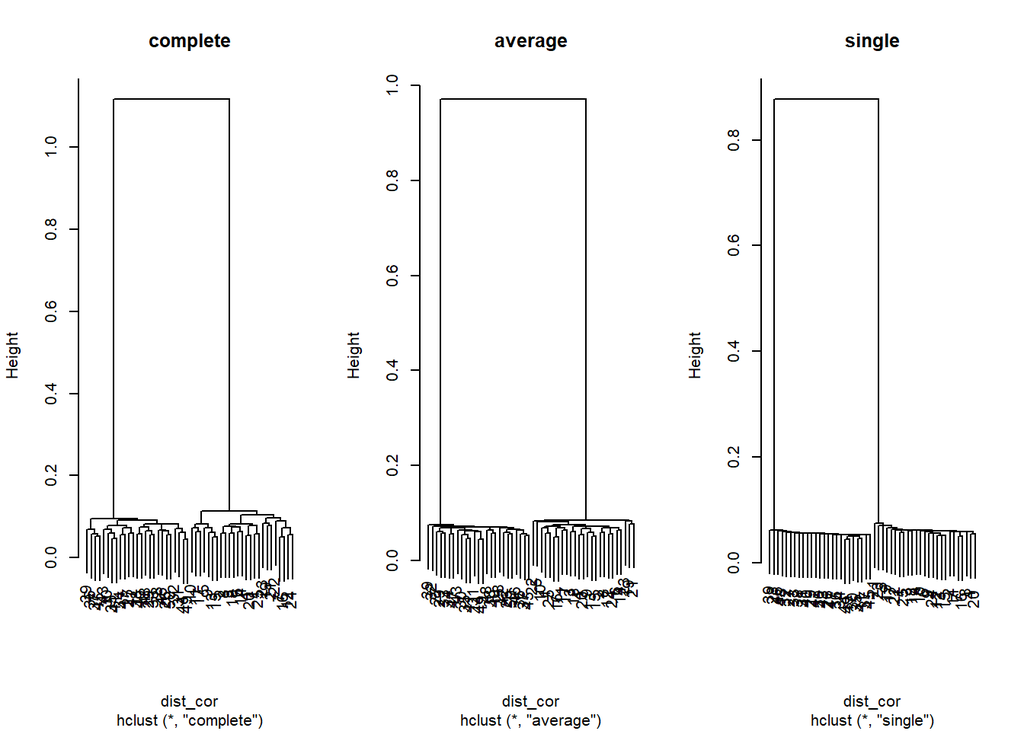

```r
correlation = cor(t(x))
dist_cor = 1 - correlation
dist_cor = as.dist(dist_cor)

hc_complete = hclust(d = dist_cor, method = "complete")
hc_average = hclust(d = dist_cor, method = "average")
hc_single = hclust(d = dist_cor, method = "single")

par(mfrow = c(1, 3))
plot(hc_complete, main = "complete")
plot(hc_average, main = "average")
plot(hc_single, main = "single")
```

```r
cutree(tree = hc_average, k = 2)
```

```
##  [1] 1 1 1 1 1 1 1 1 1 1 1 1 1 1 1 1 1 1 1 1 1 1 1 1 1 2 2 2 2 2 2 2 2 2 2
## [36] 2 2 2 2 2 2 2 2 2 2 2 2 2 2 2
```

### Reference

James, Gareth, et al. An Introduction to Statistical Learning with Applications in R. Springer, 2017.